# Advanced Biological Statistics Week 1

10/1/2018

[figure not shown]

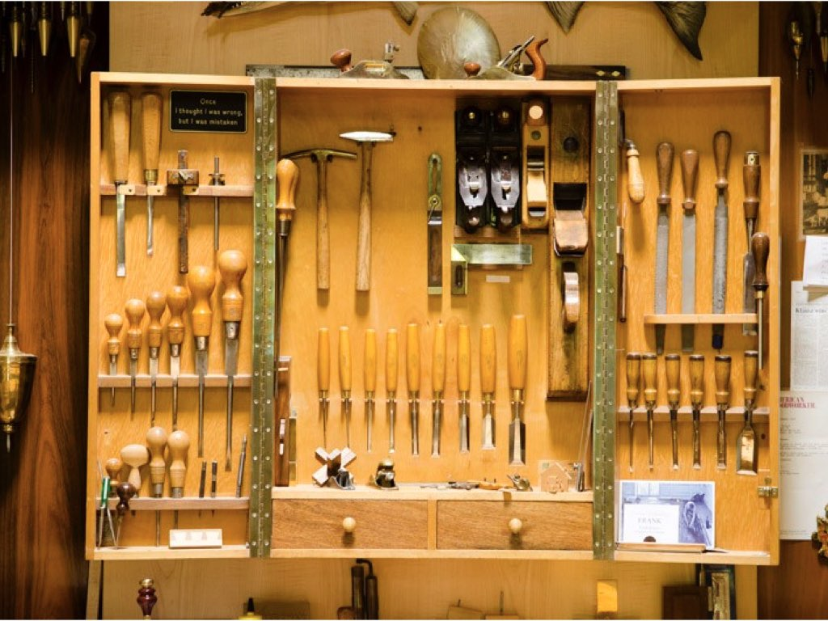

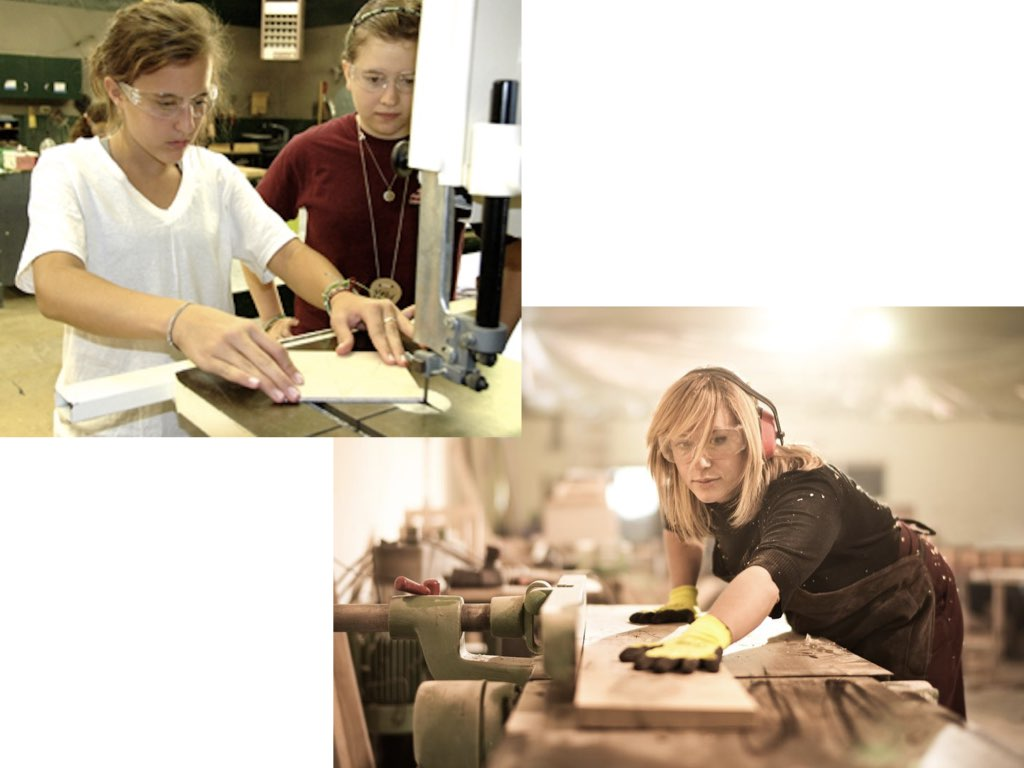

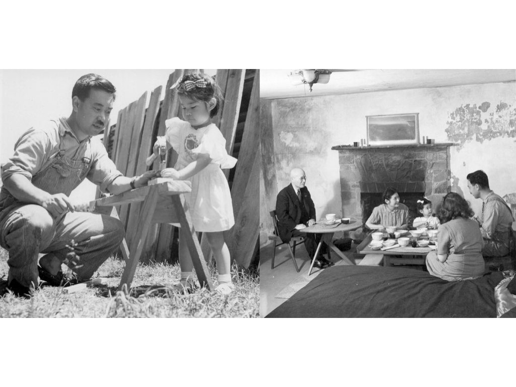

## Goals of the course

- To help you perform your research through instruction in the core components of data collection, organization, manipulation, analysis, interpretation and presentation.
- Provide a broad coverage of the core components of modern biological statistics
- Provide you with the computational tools necessary to carry out your work - namely R and affiliated tools
- This is a practical course and we will learn by doing

## Why do we need statistics?

- We almost never know the world perfectly, but still want to draw conclusions or make decisions
- We need to estimate underlying parameters from samples of data
- Sometimes we need to test hypotheses using data
- Other times we need to more succinctly summarize and/or visualize large amounts of data
- There are well known mathematical rules that help us do both
- Statistics can be done by hand, but computers let us do most of the mathematics quickly

## Why do we need statistics?

We want to turn data into conclusions about the world

- experimental design
- point estimates and confidence intervals
- hypothesis testing
- data reduction of highly dimensional data

need: a firm understanding of probability, sampling and distributions

## A biological example to get us started

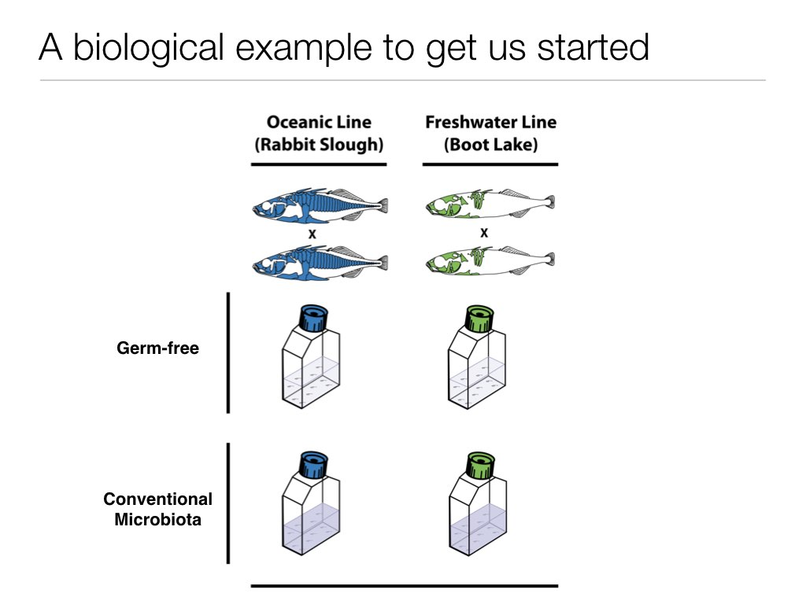

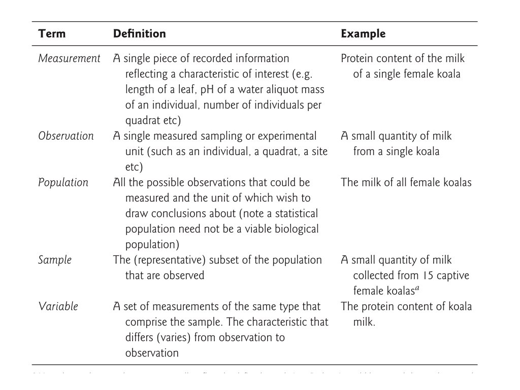

## Data set rules of thumb (aka Tidy Data)

- Store a copy of data in nonproprietary software and hardware formats, such as plain ASCII text (aka a flat file)
- Leave an uncorrected file when doing analyses
- Use descriptive names for your data files and variables
- Include a header line with descriptive variable names
- Maintain effective metadata about the data
- When you add observations to a database, add rows
- When you add variables to a database, add columns, not rows
- A column of data should contain only one data type

[figure not shown]

## Why use the command line?

- The commands work almost identically across platforms
- You can even use them on a large computer cluster like Talapas
- It is incredibly powerful particularly for repeated actions
- It allows you to do thousands of ‘clicks’ with single commands

[figure not shown]

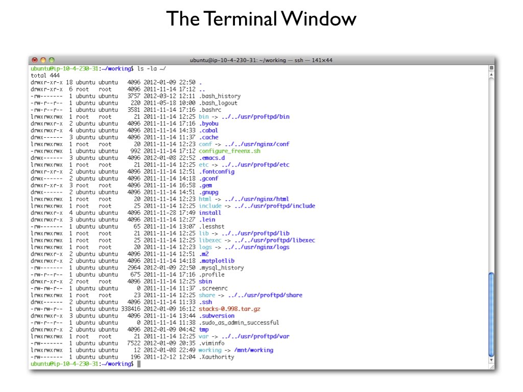

[figure not shown]

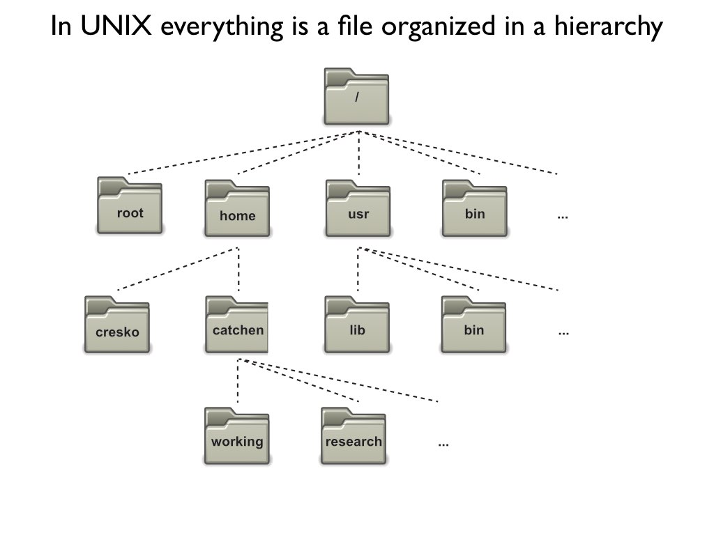

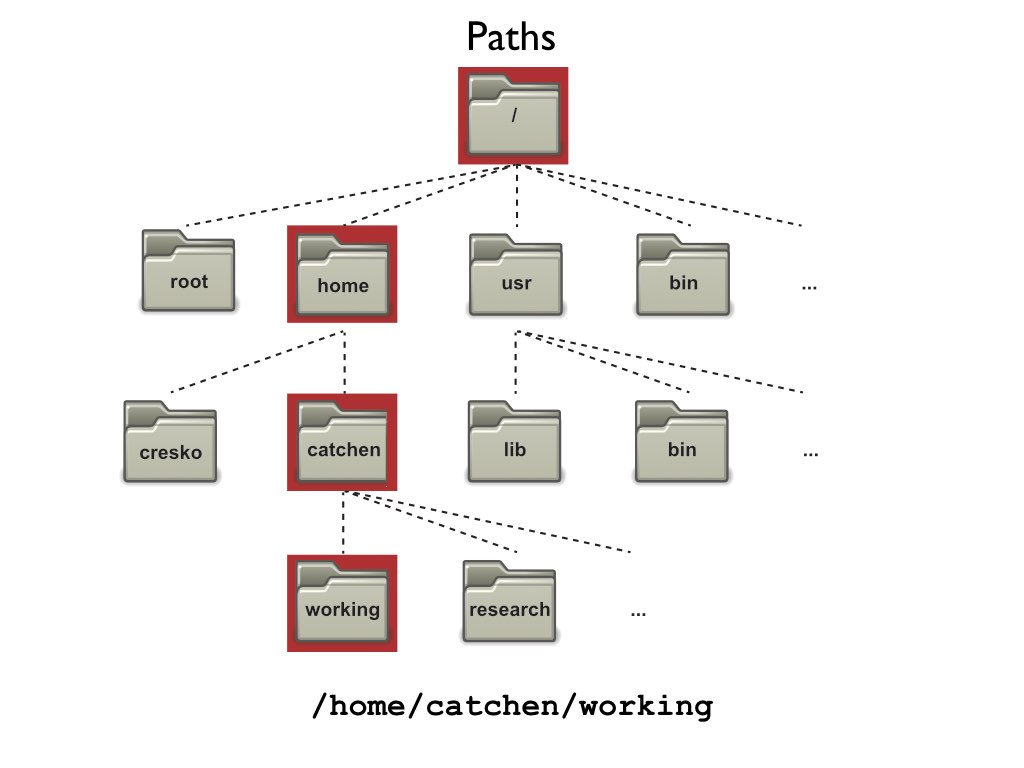

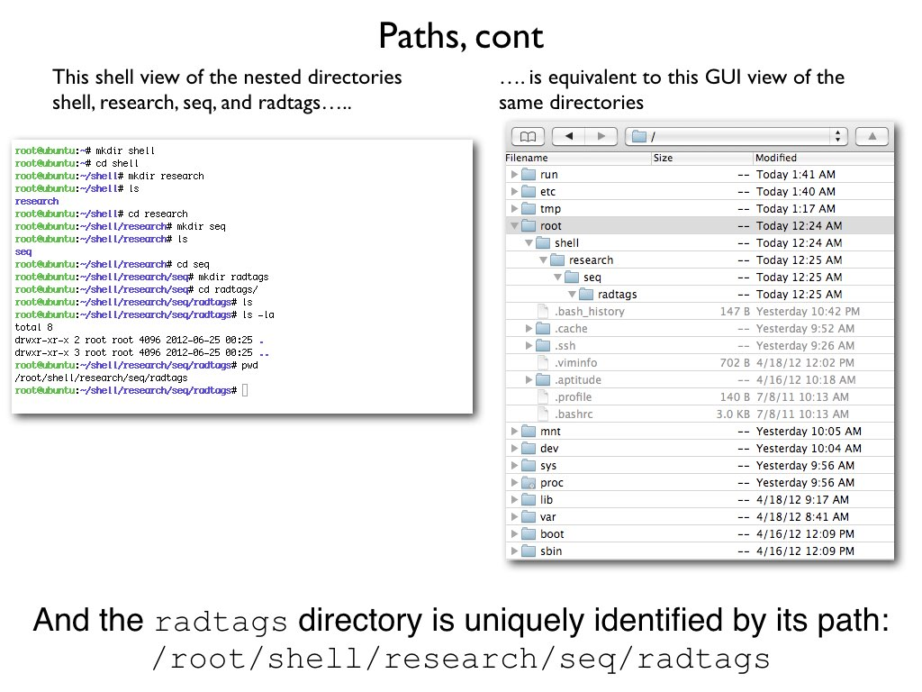

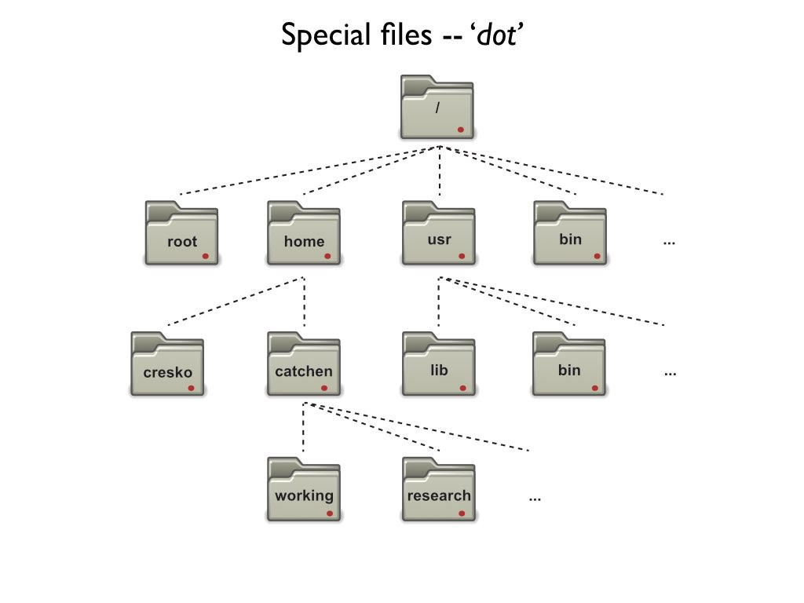

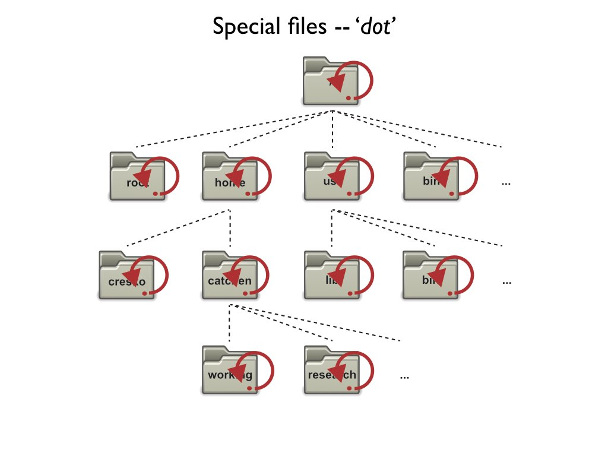

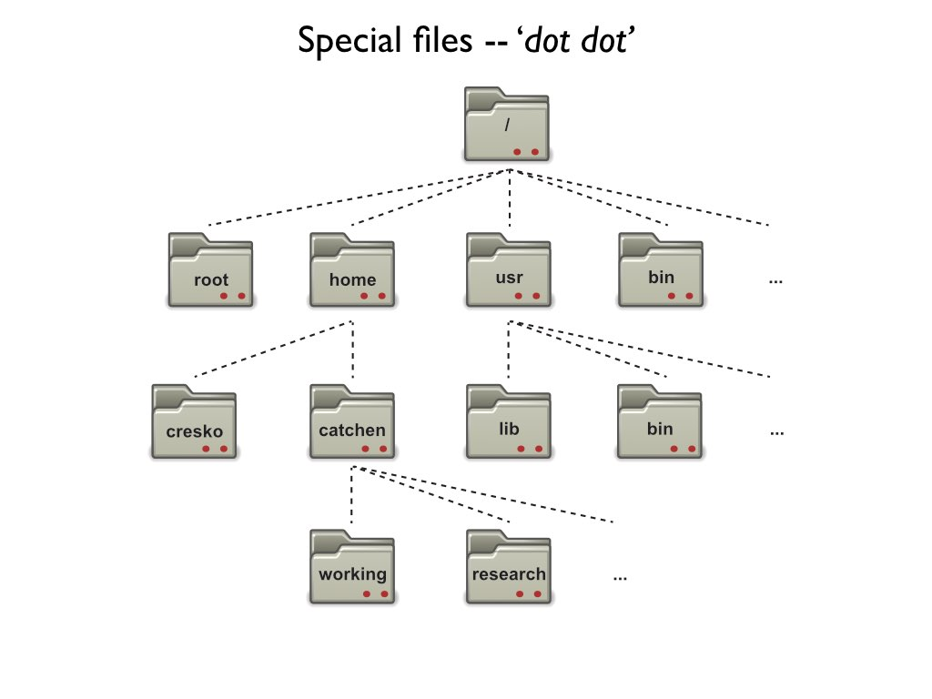

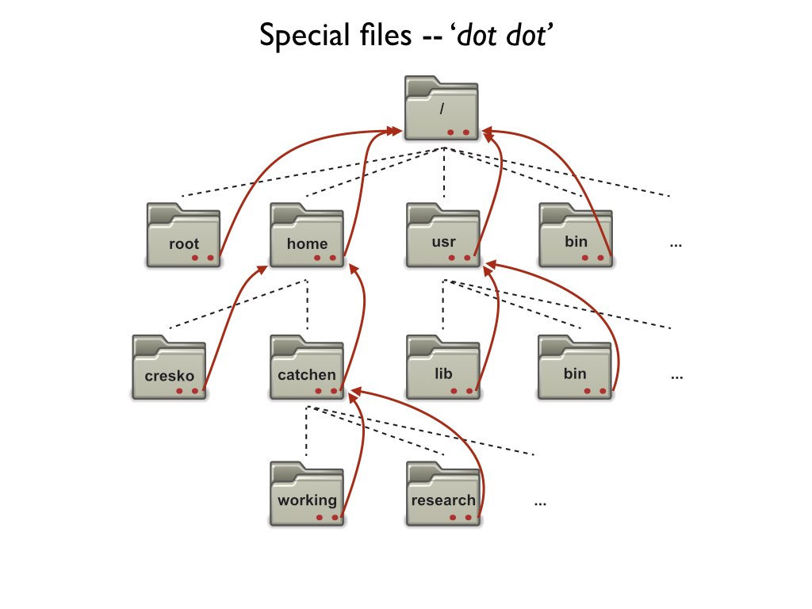

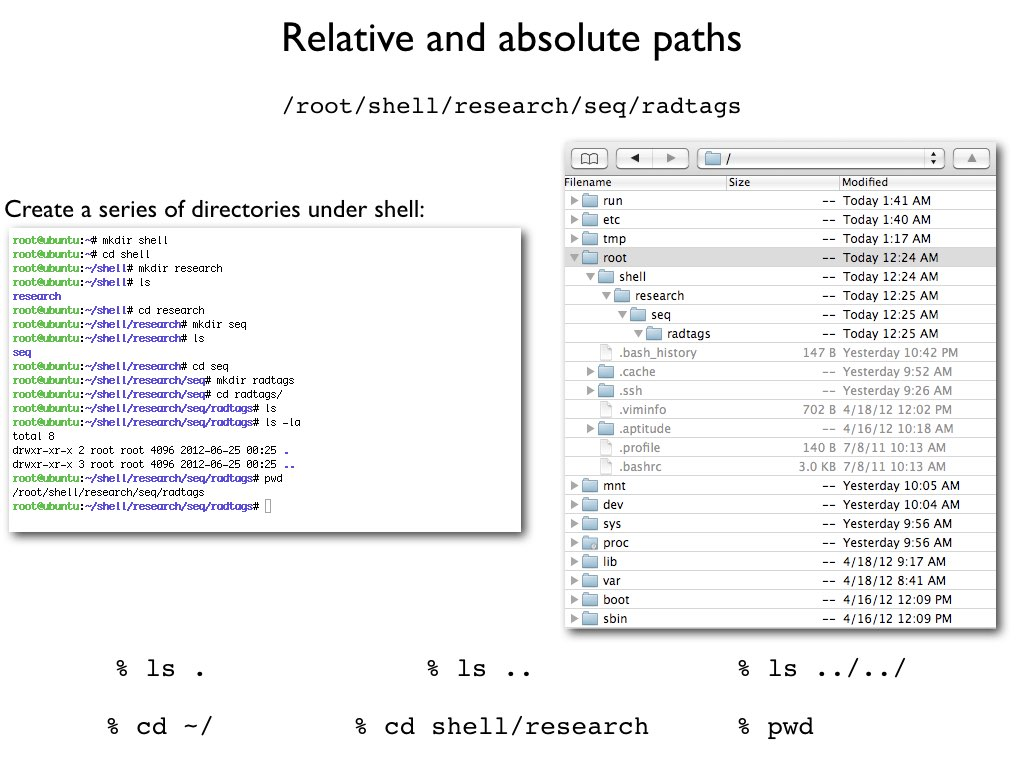

## The power of the command line

- Get a terminal application up and running on your computer
- Make sure that you can display the path to your current directory
- List the files in the current directory
- Use arguments to your list command to show all files in long form
- Move through your directories by changing your location them
- Make a new directory and put an existing text file in it
- Use the command ‘less’ to see the contents of the file
- Create a new file in the directory using ‘nano’
- Copy the files that you made into a new directory
- Delete the files and then the directory

## Why use R?

- Good general scripting tool for statistics and mathematics
- Powerful and flexible and free
- Runs on all computer platforms
- New enhancements coming out all the time
- Superb data management & graphics capabilities
- Reproducibility - can keep your scripts to see exactly what was done
- Can embed your R analyses in dynamic, polished files using R markdown
- You can write your own functions
- Lots of online help available
- Can use a nice GUI front end such as Rstudio

## AN INTRODUCTION TO GETTING STARTED WITH THE BASICS IN R

- Anything that follows ‘#’ symbol (aka hash) is just for humans
- A better way to embed code in R Markdown files
- http://kbroman.org/knitr_knutshell/pages/Rmarkdown.html
- Commands through the terminal, console or scripts

```r
4*4
```

```
## [1] 16
```

```r
(4+3*2^2)
```

```
## [1] 16
```

## Assigning Variables

- A better way to do this is to assign variables
- Variables are assigned values using the “<-” operator.
- Variable names must begin with a letter, but other than that, just
- About anything goes. Do keep in mind that R is case sensitive.

## Assigning Variables

```r
x <- 2
x*3
```

```
## [1] 6
```

```r
y <- x * 3
y-2
```

```
## [1] 4
```

These are not good

3y <- 3 3*y <- 3

## Arithmetic operations on functions

- the outcome of calculations can be assigned to new variables as well, and the results can be checked using the ‘print’ command

## Arithmetic operations on functions

```r
y <- 67
print(y)
```

```
## [1] 67
```

```r
x <- 124
z <- (x*y)^2
print(z)
```

```
## [1] 69022864
```

## STRINGS

- Variables and operations can be performed on characters as well.
- Note that characters need to be set off by quotation marks to differentiate them from numbers.
- The c stands for ‘concatenate’.
- Note that we are using the same variable names as we did previously, which means that we’re overwriting our previous assignment.
- A good rule of thumb is to use new names for each variable, and make them short but still descriptive

## STRINGS

```r
x <- "I Love"
print (x)
```

```
## [1] "I Love"
```

```r
y <- "Biostatistics"
print (y)
```

```
## [1] "Biostatistics"
```

```r
z <- c(x,y)
print (z)
```

```
## [1] "I Love"        "Biostatistics"
```

## FACTORS

- The variable z is now what is called a list of character values.
- Sometimes we would like to treat the characters as if they were units for subsequent calculations.
- These are called factors, and we can redefine our character variables as factors.
- This might seem a bit strange, but it’s important for statistical analyses where we might want to see the mean or variance for two different treatments.

## FACTORS

```r
z_factor <- as.factor(z)
print (z_factor)
```

```
## [1] I Love        Biostatistics
## Levels: Biostatistics I Love
```

- Note that factor levels are reported alphabetically

## VECTORS

- In general R thinks in terms of vectors (a list of characters, factors or numerical values) and it will benefit any R user to try to write programs with that in mind, as it will simplify most things.
- Vectors can be assigned directly using the ‘c()’ function and then entering the exact values.

## VECTORS

```r
x <- c(2,3,4,2,1,2,4,5,10,8,9)
print(x)
```

```
##  [1]  2  3  4  2  1  2  4  5 10  8  9
```

## Basic Statistics

- Many functions exist to operate on vectors.
- Combine these with your previous variable to see what happens.
- Also, try to find other functions (e.g. standard deviation).

## Basic Statistics

- mean(x)
- median(x)
- var(x)
- sum(x)
- length(x)
- sample(x, replace = T)

## Getting Help

- Getting Help on any function is very easy - just type a question mark and the name of the function.
- There are functions for just about anything within R and it is easy enough to write your own functions if none already exist to do what you want to do.
- In general, function calls have a simple structure: a function name, a set of parentheses and an optional set of parameters to send to the function.
- Help pages exist for all functions that, at a minimum, explain what parameters exist for the function.
- Help can be accessed a few ways - try them :

## Getting Help

- help(mean)
- ?mean
- example(mean)
- help.search(“mean”)
- apropos(“mean”)
- args(mean)

## Drawing samples from distributions

- Here is a way to create your own data sets that are random samples.
- Again, play around with the arguments in the parentheses to see # what happens.

## Drawing samples from distributions

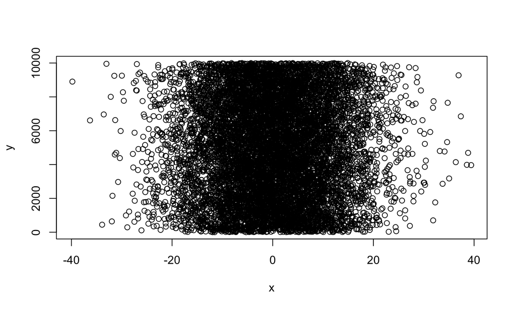

```r
x <- rnorm (10000, 0, 10)
y <- sample (1:10000, 10000, replace = T)
xy <- cbind(x,y)

plot(x,y)
plot(xy)
```

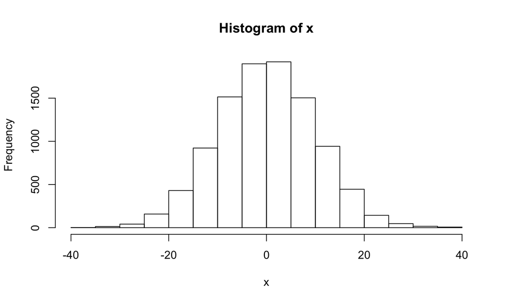

```r
hist(x)
```

## Drawing samples from distributions

- You’ve probably figured out that y from the last example is drawing numbers with equal probability.
- What if you want to draw from a distribution?
- Again, play around with the arguments in the parentheses to see what happens.

## Drawing samples from distributions

[figure not shown]

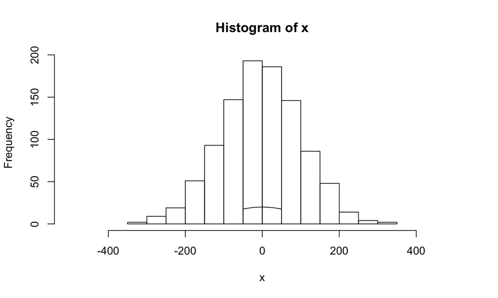

- dnorm() generates the probability density, which can be plotted using the curve() function. - Note that is curve is added to the plot using add=TRUE

## Visualizing Data

- So far you’ve been visualizing just the list of output numbers
- Except for the last example where I snuck in a ‘hist’ function.
- You can also visualize all of the variables that you’ve created using the ‘plot’ function (as well as a number of more sophisticated plotting functions).
- Each of these is called a ‘high level’ plotting function, which sets the stage
- ‘Low level’ plotting functions will tweak the plots and make them beautiful

## Visualizing Data

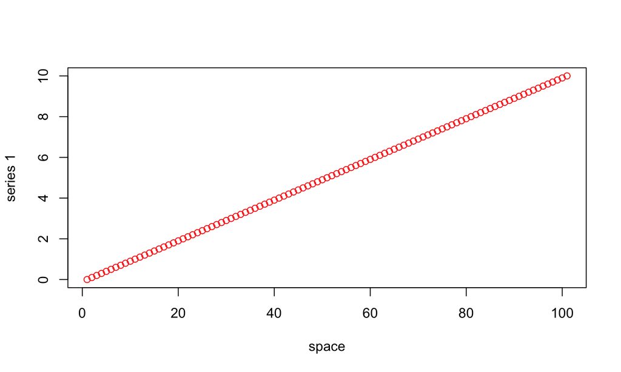

## Putting plots in a single figure

- The first line of the lower script tells R that you are going to create a composite figure that has two rows and two columns. Can you tell how?
- Now, modify the cody to add two more variables and add one more row of two panels.

## Putting plots in a single figure

```r
seq_1 <- seq(0.0, 10.0, by = 0.1)
print(seq_1)
```

```
##   [1]  0.0  0.1  0.2  0.3  0.4  0.5  0.6  0.7  0.8  0.9  1.0  1.1  1.2  1.3
##  [15]  1.4  1.5  1.6  1.7  1.8  1.9  2.0  2.1  2.2  2.3  2.4  2.5  2.6  2.7
##  [29]  2.8  2.9  3.0  3.1  3.2  3.3  3.4  3.5  3.6  3.7  3.8  3.9  4.0  4.1
##  [43]  4.2  4.3  4.4  4.5  4.6  4.7  4.8  4.9  5.0  5.1  5.2  5.3  5.4  5.5
##  [57]  5.6  5.7  5.8  5.9  6.0  6.1  6.2  6.3  6.4  6.5  6.6  6.7  6.8  6.9
##  [71]  7.0  7.1  7.2  7.3  7.4  7.5  7.6  7.7  7.8  7.9  8.0  8.1  8.2  8.3
##  [85]  8.4  8.5  8.6  8.7  8.8  8.9  9.0  9.1  9.2  9.3  9.4  9.5  9.6  9.7
##  [99]  9.8  9.9 10.0
```

```r
seq_2 <- seq(10.0, 0.0, by = -0.1)
print(seq_2)
```

```
##   [1] 10.0  9.9  9.8  9.7  9.6  9.5  9.4  9.3  9.2  9.1  9.0  8.9  8.8  8.7
##  [15]  8.6  8.5  8.4  8.3  8.2  8.1  8.0  7.9  7.8  7.7  7.6  7.5  7.4  7.3
##  [29]  7.2  7.1  7.0  6.9  6.8  6.7  6.6  6.5  6.4  6.3  6.2  6.1  6.0  5.9
##  [43]  5.8  5.7  5.6  5.5  5.4  5.3  5.2  5.1  5.0  4.9  4.8  4.7  4.6  4.5
##  [57]  4.4  4.3  4.2  4.1  4.0  3.9  3.8  3.7  3.6  3.5  3.4  3.3  3.2  3.1
##  [71]  3.0  2.9  2.8  2.7  2.6  2.5  2.4  2.3  2.2  2.1  2.0  1.9  1.8  1.7
##  [85]  1.6  1.5  1.4  1.3  1.2  1.1  1.0  0.9  0.8  0.7  0.6  0.5  0.4  0.3
##  [99]  0.2  0.1  0.0
```

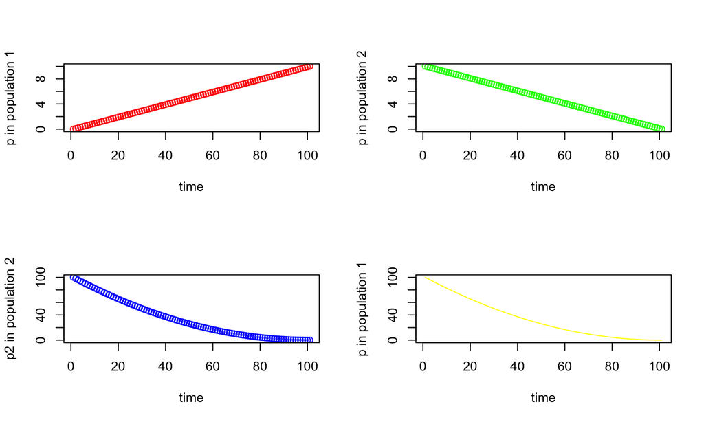

```r
par(mfrow=c(2,2))
plot (seq_1, xlab="time", ylab ="p in population 1", type = "p", col = 'red')
plot (seq_2, xlab="time", ylab ="p in population 2", type = "p", col = 'green')
plot (seq_square, xlab="time", ylab ="p2 in population 2", type = "p", col = 'blue')
plot (seq_square_new, xlab="time", ylab ="p in population 1", type = "l", col = 'yellow')
```

## Example using binomial distribution

- As above for the normal distribution, data can be generated by being sampled from nearly any distribution and then visualized.
- Below I’m having you use the ‘histogram’ function. What does it do?

## Example using binomial distribution

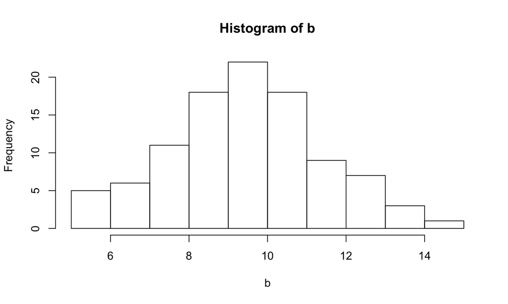

```r
b <- rbinom(n=100, size=20, prob=0.5)
hist(b)
```

- 10 successes (out of 20 trials) is the most frequent outcome - This kind of statement can be run in one line as well, which is sometimes easier.

## Example using binomial distribution

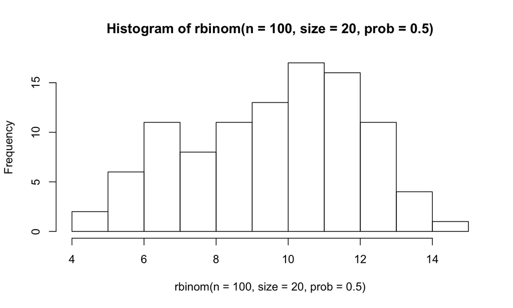

```r
hist(rbinom(n=100, size=20, prob=0.5))
```

## Creating Data Frames in R

- As you have seen, in R you can generate your own random data set drawn from nearly any distribution very easily. Often we will want to use collected data.
- Now, let’s make a dummy dataset to get used to dealing with data frames
- Set up three variables (habitat, temp and elevation) as vectors

```r
habitat <- factor(c("mixed", "wet", "wet", "wet", "dry", "dry", "dry","mixed"))
temp <- c(3.4, 3.4, 8.4, 3, 5.6, 8.1, 8.3, 4.5)
elevation <- c(0, 9.2, 3.8, 5, 5.6, 4.1, 7.1, 5.3)
```

Create a data frame where vectors become columns

```r
mydata <- data.frame(habitat, temp, elevation)
row.names(mydata) <- c("Reedy Lake", "Pearcadale", "Warneet", "Cranbourne", "Lysterfield", "Red Hill", "Devilbend", "Olinda")
```

## Reading in Data Frames in R

- A strength of R is being able to import data from an external source
- Create the same table that you did above in a spreadsheet like Excel.
- Export it to comma separated and tab separated text files for importing into R.
- The first will read in a comma-delimited file, whereas the second is a tab-delimited.
- In both cases the header and row.names arguments indicate that there is a header row and row label column.
- Note that the name of the file by itself will have R look in the CWD, whereas a full path can also be used.

## Reading in Data Frames in R

- YourFile <- read.table(‘yourfile.csv’, header=T, row.names=1, sep=‘,’)
- YourFile <- read.table(‘yourfile.txt’, header=T, row.names=1, sep=’)

## Exporting Data Frames in R

- write.table(YourFile, “yourfile.csv”, quote=F, row.names=T, sep=“,”)
- write.table(YourFile, “yourfile.txt”, quote=F, row.names=T, sep=")

## Some real transcriptomic data

- Examine the text file: GacuRNAseq_Subset.csv
- How many many rows and columns are there?
- How many different variables are there?
- What are the general types of variables?
- Now let’s read the data file into R and analyze it

## Some real transcriptomic data

- This exercise will help you get used to reading in and manipulating genomic data files
- First off, remember to set your working directory to find your file correctly

## Some real transcriptomic data

- RNAseq_Data <- read.table(‘GacuRNAseq_subset.csv’, header=TRUE, sep=‘,’)
- print (RNAseq_Data)
- head (RNAseq_Data)
- tail (RNAseq_Data)
- print (RNAseq_Data[,2])
- print (RNAseq_Data[1,])
- print (RNAseq_Data[1,2])
- print (RNAseq_Data$ENSGACG00000000010)
- print (RNAseq_Data$ENSGACG00000000010>45.0)